# 03_Link_DataPop_Models_v2

## 1.5) Balanceamento "Oversample" ADASUYN

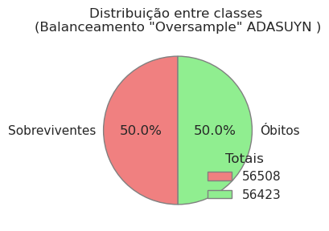

|  | 0 | 1 | 2 |
| --- | --- | --- | --- |
|  | Validação | Treino | Teste |
| sobreviventes | 17671 | 56508 | 14130 |
| óbitos neonatais | 115 | 56423 | 99 |

```python
adasyn = ADASYN(sampling_strategy='minority')
X_over, y_over = adasyn.fit_resample(X_train, y_train)

data = {'': ['Validação', 'Treino', 'Teste'],
        'sobreviventes': [y_val.value_counts()[0], y_over.value_counts()[0], y_test.value_counts()[0]],
        'óbitos neonatais': [y_val.value_counts()[1], y_over.value_counts()[1], y_test.value_counts()[1]]}

plot_donut_chart(pd.concat([X_over, y_over], axis=1), '\n(Balanceamento "Oversample" ADASUYN )')

pd.DataFrame(data).T.to_csv('dados_oversample_ADASUYN.csv', header=False)
pd.DataFrame(data).T
```

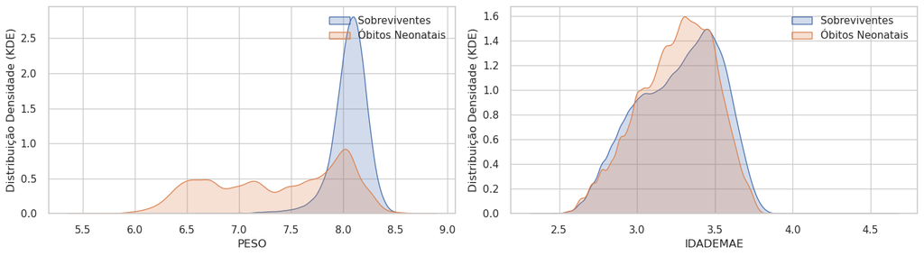

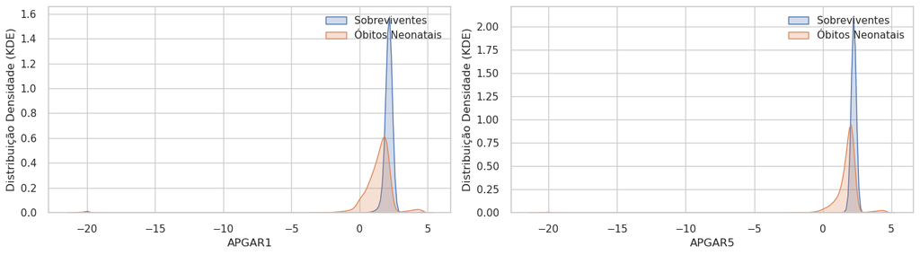

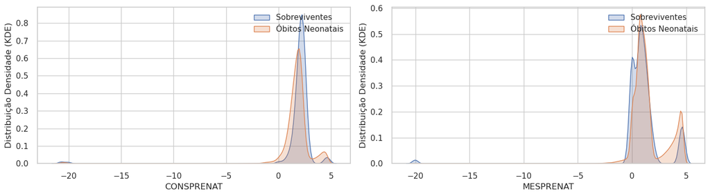

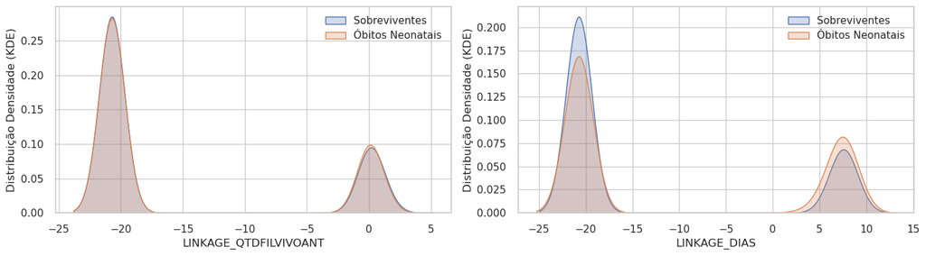

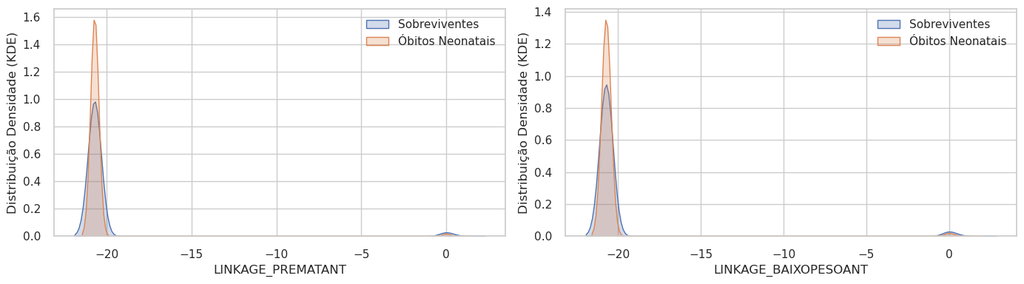

```python
# Plot KDEs
column_pairs = [('PESO', 'IDADEMAE'),
                ('APGAR1', 'APGAR5'),
                ('CONSPRENAT', 'MESPRENAT'),
                ('LINKAGE_QTDFILVIVOANT', 'LINKAGE_DIAS'),
                ('LINKAGE_PREMATANT', 'LINKAGE_BAIXOPESOANT')]

for column_pair in column_pairs:
    plot_weight_distribution(X_over, y_over, *column_pair)
```

## 1.6) Normalização de features

```python
# Store the feature names before scaling
feature_names = X_80.columns.tolist()

file_path = folder + 'X_train.pkl'

# Ler os arrays de arquivos pickle caso existam
if os.path.exists(file_path):
  # Load Base 80/20
  with open(folder + 'X_train.pkl', 'rb') as f:
      X_train = pickle.load(f)

  with open(folder + 'X_test.pkl', 'rb') as f:
      X_test = pickle.load(f)

  with open(folder + 'X_val.pkl', 'rb') as f:
      X_val = pickle.load(f)

  # Load Base balanceada Undersampling
  with open(folder + 'X_train_bal.pkl', 'rb') as f:
      X_train_bal = pickle.load(f)

  with open(folder + 'X_test_bal.pkl', 'rb') as f:
      X_test_bal = pickle.load(f)

  with open(folder + 'X_val_bal.pkl', 'rb') as f:
      X_val_bal = pickle.load(f)

  # Load Base balanceada Undersampling ENN
  with open(folder + 'X_train_enn.pkl', 'rb') as f:
      X_train_enn = pickle.load(f)

  with open(folder + 'X_test_enn.pkl', 'rb') as f:
      X_test_enn = pickle.load(f)

  with open(folder + 'X_val_enn.pkl', 'rb') as f:
      X_val_enn = pickle.load(f)

  with open(folder + 'X_over.pkl', 'rb') as f:
      X_over = pickle.load(f)

  with open(folder + 'y_over.pkl', 'rb') as f:
      y_over = pickle.load(f)

  # ONE CLASS
  with open(folder + 'X_train_one_class.pkl', 'rb') as f:
      X_train_one_class = pickle.load(f)

  with open(folder + 'y_train_one_class.pkl', 'rb') as f:
      y_train_one_class = pickle.load(f)
  """
  with open(folder + 'X_train_class0.pkl', 'rb') as f:
      X_train_class0 = pickle.load(f)

  with open(folder + 'X_test_class0.pkl', 'rb') as f:
      X_test_class0 = pickle.load(f)

  with open(folder + 'X_outliers.pkl', 'rb') as f:
      X_outliers = pickle.load(f)

  with open(folder + 'X_test_both.pkl', 'rb') as f:
      X_test_both = pickle.load(f)
  """
# Caso não exista, normaliza e cria os arquivos
else:

  # Normalização
  scaler = MinMaxScaler()

  # Base 80/20
  X_train = scaler.fit_transform(X_train)
  X_test = scaler.fit_transform(X_test)
  X_val = scaler.fit_transform(X_val)

  # Base balanceada Undersampling
  X_train_bal = scaler.fit_transform(X_train_bal)
  X_test_bal = scaler.fit_transform(X_test_bal)
  X_val_bal = scaler.fit_transform(X_val_bal)

  # Base balanceada Undersampling ENN
  X_train_enn = scaler.fit_transform(X_train_enn)
  X_test_enn = scaler.fit_transform(X_test_enn)
  X_val_enn = scaler.fit_transform(X_val_enn)

  X_over = scaler.fit_transform(X_over)

  # Dados para abordagem ONE CLASS
  X_train_one_class = scaler.fit_transform(X_train_one_class)

  #X_train_class0 = scaler.fit_transform(X_train_class0)
  #X_test_class0 = scaler.fit_transform(X_test_class0)
  #X_outliers = scaler.fit_transform(X_outliers)
  #X_test_both = scaler.fit_transform(X_test_both)

  # Salvando dados em Pickles ......

  with open(folder + 'X_train.pkl', 'wb') as f:
      pickle.dump(X_train, f)

  with open(folder + 'X_test.pkl', 'wb') as f:
      pickle.dump(X_test, f)

  with open(folder + 'X_val.pkl', 'wb') as f:
      pickle.dump(X_val, f)

  # Save Base balanceada Undersampling
  with open(folder + 'X_train_bal.pkl', 'wb') as f:
      pickle.dump(X_train_bal, f)

  with open(folder + 'X_test_bal.pkl', 'wb') as f:
      pickle.dump(X_test_bal, f)

  with open(folder + 'X_val_bal.pkl', 'wb') as f:
      pickle.dump(X_val_bal, f)

  # Save Base balanceada Undersampling ENN
  with open(folder + 'X_train_enn.pkl', 'wb') as f:
      pickle.dump(X_train_enn, f)

  with open(folder + 'X_test_enn.pkl', 'wb') as f:
      pickle.dump(X_test_enn, f)

  with open(folder + 'X_val_enn.pkl', 'wb') as f:
      pickle.dump(X_val_enn, f)

  with open(folder + 'X_over.pkl', 'wb') as f:
      pickle.dump(X_over, f)

  with open(folder + 'y_over.pkl', 'wb') as f:
      pickle.dump(y_over, f)

  with open(folder + 'X_train_one_class.pkl', 'wb') as f:
      pickle.dump(X_train_one_class, f)

  with open(folder + 'y_train_one_class.pkl', 'wb') as f:
      pickle.dump(y_train_one_class, f)

"""
  with open(folder + 'X_train_class0.pkl', 'wb') as f:
      pickle.dump(X_train_class0, f)

  with open(folder + 'X_test_class0.pkl', 'wb') as f:
      pickle.dump(X_test_class0, f)

  with open(folder + 'X_outliers.pkl', 'wb') as f:
      pickle.dump(X_outliers, f)

  with open(folder + 'X_test_both.pkl', 'wb') as f:
      pickle.dump(X_test_both, f)

"""
```

[output not shown]

# CHECKPOINT 1 -> EXPERIMENTOS

Os experimentos envolveram quatro conjuntos de algoritmos de aprendizado de máquina. Inicialmente, foram conduzidos experimentos utilizando regressão logística para estabelecer um modelo de referência. A regressão logística é uma técnica estatística que modela a probabilidade de ocorrência de um evento. Em seguida, prosseguimos com experimentos empregando o algoritmo Naive Bayes, um método probabilístico baseado no teorema de Bayes, especialmente eficaz em problemas de classificação de texto.

Posteriormente, aplicamos o algoritmo XGBoost, uma implementação otimizada de boosting que utiliza árvores de decisão, destacando-se pela eficiência em problemas complexos e grande quantidade de dados. Por fim, adotamos a abordagem oneclass, utilizando os algoritmos de SVM (Support Vector Machine) e Isolation Forest. O SVM é conhecido por separar dados em diferentes classes, sendo utilizado na detecção de anomalias quando treinado com exemplos normais. O Isolation Forest, por sua vez, é um algoritmo baseado em árvores projetado para isolar anomalias de forma eficiente em conjuntos de dados extensos. Essa diversidade de algoritmos permite explorar diferentes abordagens e maximizar a eficácia na resolução de problemas específicos.

# E1: Regressão Logística

#### **Descrição**

Este código realiza a classificação usando um modelo de regressão logística simples, avalia o desempenho do modelo e gera visualizações para a curva ROC, a importância das features e os valores SHAP.

O código começa dividindo o conjunto de dados em conjuntos de treinamento e teste, essenciais para avaliar o desempenho do modelo. Em seguida, ele cria um modelo de classificação de Regressão Logística, que é um método amplamente utilizado para problemas de classificação binária. O modelo é treinado usando os dados de treinamento e usado para fazer previsões nos dados de teste.

Avaliando o desempenho, o código calcula a acurácia do modelo, que é a proporção de previsões corretas em relação ao total de previsões. Também calcula a Área sob a Curva ROC (AUC-ROC), que mede a capacidade do modelo de distinguir entre classes positivas e negativas. Os resultados são satisfatórios se a acurácia for alta e o AUC-ROC estiver próximo de 1, indicando que o modelo está fazendo previsões precisas.

Além disso, o código gera gráficos informativos. A curva ROC mostra o equilíbrio entre a taxa de falsos positivos e a taxa de verdadeiros positivos, enquanto o gráfico de importância das features destaca quais características têm maior influência nas previsões do modelo. Por fim, os valores SHAP são calculados para explicar a contribuição de cada feature em cada previsão.

Em resumo, o código apresenta um modelo de Regressão Logística para classificação binária e avalia seu desempenho usando métricas como acurácia e AUC-ROC, ao mesmo tempo em que fornece insights visuais sobre a importância das features e os valores SHAP. Estas análises são fundamentais para entender como o modelo toma suas decisões e quais características são mais relevantes para as previsões.

## E1-a: Regressão Logística - Baseline

O modelo de Regressão Logística foi inicialmente criado com todos os parâmetros configurados com valores padrão. Para que o modelo pudesse convergir para a solução ótima, foi necessário ajustar o parâmetro "max_iter" para o valor de 1.000. Este parâmetro determina o número máximo de iterações que o algoritmo utilizará para convergir para uma solução, ou seja, define o limite de vezes que o algoritmo ajustará os coeficientes do modelo para otimizar a função de custo e encontrar os parâmetros que melhor se ajustam aos dados de treinamento.

Caso o algoritmo não atinja uma solução dentro do número especificado de iterações, uma mensagem de aviso de não convergência pode ser gerada. Aumentar o valor de "max_iter" pode resolver esse problema, permitindo que o algoritmo execute mais iterações na tentativa de encontrar uma solução adequada.

Entretanto, é essencial equilibrar o valor de "max_iter", pois um valor muito alto pode significativamente aumentar o tempo de treinamento do modelo, especialmente em conjuntos de dados grandes. Em resumo, o parâmetro "max_iter" desempenha um papel crucial no controle da convergência da regressão logística e deve ser ajustado de acordo com a complexidade do problema e os recursos computacionais disponíveis.

```
-------------------------------------------------------------
E1-a : Regressão Logística - Baseline - LogisticRegression
-------------------------------------------------------------
Relatório de Classificação:
          index  precision  recall  f1-score  support
0             0       0.99    1.00      1.00    14130
1             1       0.86    0.06      0.11       99
2      accuracy       0.99    0.99      0.99        0
3     macro avg       0.93    0.53      0.55    14229
4  weighted avg       0.99    0.99      0.99    14229
-------------------------------------------------------------
```

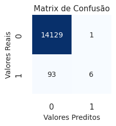

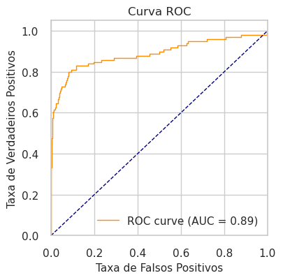

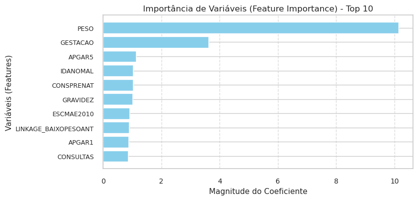

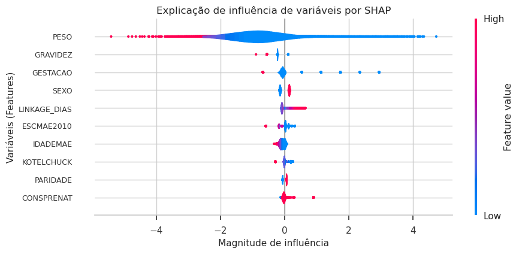

```
-------------------------------------------------------------
E1-av: Validação - LogisticRegression
-------------------------------------------------------------
Relatório de Classificação:
          index  precision  recall  f1-score  support
0             0       0.99    1.00      1.00    17671
1             1       0.57    0.07      0.12      115
2      accuracy       0.99    0.99      0.99        0
3     macro avg       0.78    0.53      0.56    17786
4  weighted avg       0.99    0.99      0.99    17786
-------------------------------------------------------------
Accuracy: 0.993646688406612
Confusion Matrix
[[17665     6]
 [  107     8]]
```

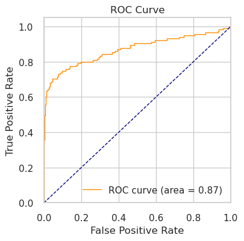

```
{'C': 1.0,
 'class_weight': None,
 'dual': False,
 'fit_intercept': True,
 'intercept_scaling': 1,
 'l1_ratio': None,
 'max_iter': 1000,
 'multi_class': 'auto',
 'n_jobs': None,
 'penalty': 'l2',
 'random_state': 42,
 'solver': 'lbfgs',
 'tol': 0.0001,
 'verbose': 0,
 'warm_start': False}
```

```python
final_report, E1_a = run_experiment('E1-a : Regressão Logística - Baseline',
                              LogisticRegression(random_state=42, max_iter=1000),
                              X_train, y_train, X_test, y_test, X_val, y_val,
                              final_report)
E1_a.get_params()
```

## E1-b: Regressão Logística - Balanceamento "Undersample" com amostragem aleatória

#### Simple Plan

```
-------------------------------------------------------------
E1-b : Regressão Logística - Balanceamento "Undersample" com amostragem aleatória - Base - LogisticRegression
-------------------------------------------------------------
Relatório de Classificação:
          index  precision  recall  f1-score  support
0             0       1.00    0.94      0.97    14130
1             1       0.07    0.73      0.13       99
2      accuracy       0.93    0.93      0.93        0
3     macro avg       0.54    0.83      0.55    14229
4  weighted avg       0.99    0.93      0.96    14229
-------------------------------------------------------------
```

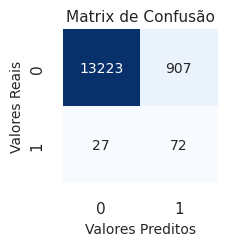

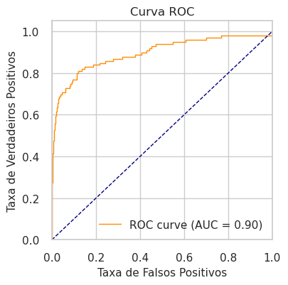

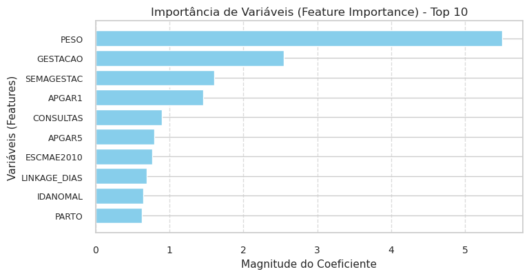

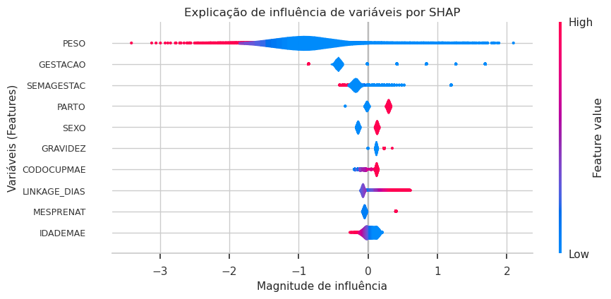

```
-------------------------------------------------------------
E1-bv: Validação - LogisticRegression
-------------------------------------------------------------
Relatório de Classificação:
          index  precision  recall  f1-score  support
0             0       1.00    0.90      0.95    17671
1             1       0.05    0.74      0.09      115
2      accuracy       0.90    0.90      0.90        0
3     macro avg       0.52    0.82      0.52    17786
4  weighted avg       0.99    0.90      0.94    17786
-------------------------------------------------------------
Accuracy: 0.9017766782862926
Confusion Matrix
[[15954  1717]
 [   30    85]]
```

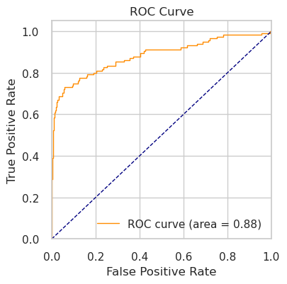

```python
_, _ = run_experiment('E1-b : Regressão Logística - Balanceamento "Undersample" com amostragem aleatória - Base',
                              LogisticRegression(random_state=42),
                              X_train_bal, y_train_bal, X_test, y_test, X_val, y_val,
                              final_report)
```

#### Model

```
-------------------------------------------------------------
E1-b : Regressão Logística - Balanceamento "Undersample" com amostragem aleatória - LogisticRegression
-------------------------------------------------------------
Relatório de Classificação:
          index  precision  recall  f1-score  support
0             0       1.00    0.82      0.90    14130
1             1       0.03    0.82      0.06       99
2      accuracy       0.82    0.82      0.82        0
3     macro avg       0.51    0.82      0.48    14229
4  weighted avg       0.99    0.82      0.90    14229
-------------------------------------------------------------
```

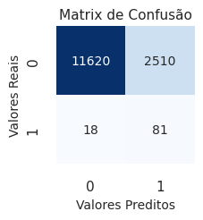

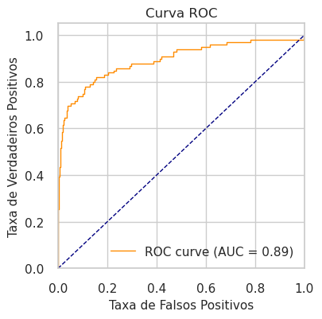

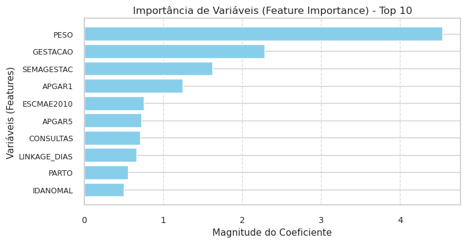

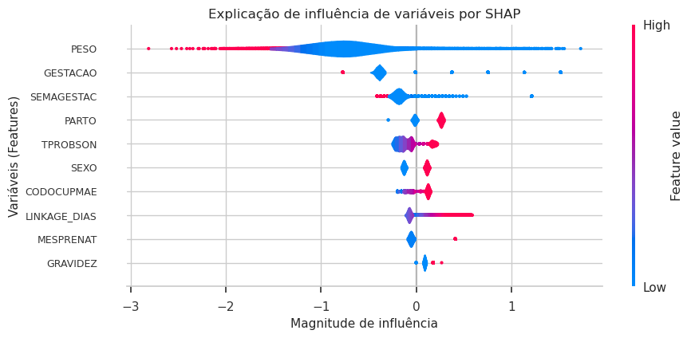

```
-------------------------------------------------------------
E1-bv: Validação - LogisticRegression
-------------------------------------------------------------
Relatório de Classificação:
          index  precision  recall  f1-score  support
0             0       1.00    0.72      0.84    17671
1             1       0.02    0.85      0.04      115
2      accuracy       0.72    0.72      0.72        0
3     macro avg       0.51    0.79      0.44    17786
4  weighted avg       0.99    0.72      0.83    17786
-------------------------------------------------------------
Accuracy: 0.7188800179916789
Confusion Matrix
[[12688  4983]
 [   17    98]]
```

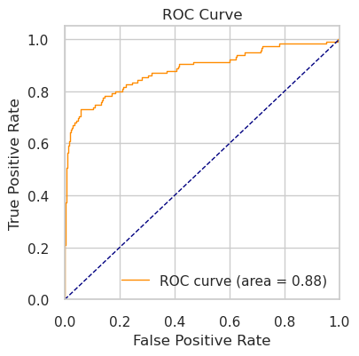

```python
final_report, E1_b = run_experiment('E1-b : Regressão Logística - Balanceamento "Undersample" com amostragem aleatória',
                              LogisticRegression(random_state=42, max_iter=1000, class_weight={0:0.455,1:1}),
                              X_train_bal, y_train_bal, X_test, y_test, X_val, y_val,
                              final_report)
```

## E1-c: Regressão Logística - Validação Cruzada

#### Simple Plan

```python
#LR = LogisticRegressionCV(random_state=42, max_iter=1000, cv=5).fit(X_train, y_train)
#initial_evaluation(LR, X_val, y_val)
```

#### Model

```
-------------------------------------------------------------
E1-c : Regressão Logística - Validação Cruzada - LogisticRegressionCV
-------------------------------------------------------------
Relatório de Classificação:
          index  precision  recall  f1-score  support
0             0       1.00    0.98      0.99    14130
1             1       0.16    0.56      0.25       99
2      accuracy       0.98    0.98      0.98        0
3     macro avg       0.58    0.77      0.62    14229
4  weighted avg       0.99    0.98      0.98    14229
-------------------------------------------------------------
```

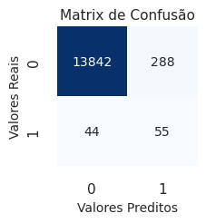

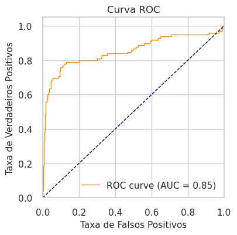

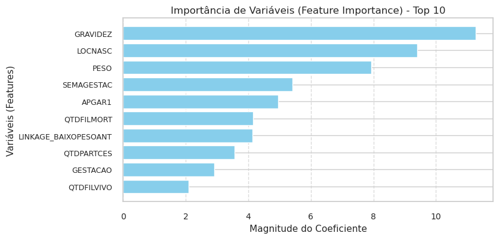

```
-------------------------------------------------------------
E1-cv: Validação - LogisticRegressionCV
-------------------------------------------------------------
Relatório de Classificação:
          index  precision  recall  f1-score  support
0             0       1.00    0.98      0.99    17671
1             1       0.16    0.60      0.25      115
2      accuracy       0.98    0.98      0.98        0
3     macro avg       0.58    0.79      0.62    17786
4  weighted avg       0.99    0.98      0.98    17786
-------------------------------------------------------------
Accuracy: 0.976554593500506
Confusion Matrix
[[17300   371]
 [   46    69]]
```

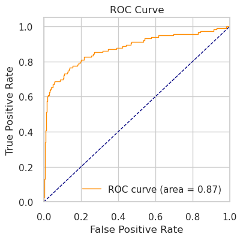

```python
# Alto custo computacional

final_report, E1_c= run_experiment('E1-c : Regressão Logística - Validação Cruzada',
                              LogisticRegressionCV(random_state=42,
                                                 max_iter=1000,
                                                 class_weight={0:0.0028,1:1}),
                              X_train, y_train, X_test, y_test, X_val, y_val,
                              final_report)
```

## E1-d: Regressão Logística - Balanceamento "Undersample" ENN

#### Simple Plan

```
Accuracy: 0.9925277929651904
Confusion Matrix
[[5382    0]
 [  41   64]]
```

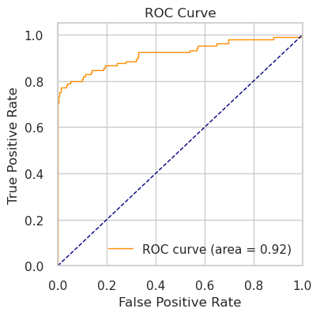

```python
LR = LogisticRegression(random_state=42, max_iter=1000).fit(X_train_enn, y_train_enn)
initial_evaluation(LR, X_test_enn, y_test_enn)
```

#### Model

```
-------------------------------------------------------------
E1-d : Regressão Logística - Balanceamento "Undersample" com ENN - LogisticRegression
-------------------------------------------------------------
Relatório de Classificação:
          index  precision  recall  f1-score  support
0             0       1.00    0.84      0.91     5382
1             1       0.09    0.83      0.17      105
2      accuracy       0.84    0.84      0.84        0
3     macro avg       0.54    0.84      0.54     5487
4  weighted avg       0.98    0.84      0.90     5487
-------------------------------------------------------------
```

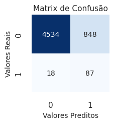

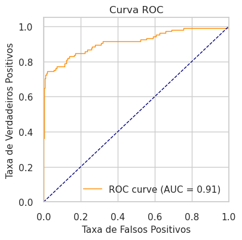

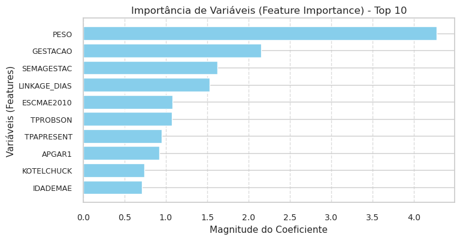

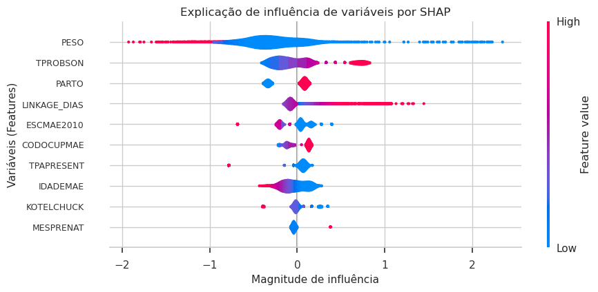

```
-------------------------------------------------------------
E1-dv: Validação - LogisticRegression
-------------------------------------------------------------
Relatório de Classificação:
          index  precision  recall  f1-score  support
0             0       1.00    0.44      0.61    17671
1             1       0.01    0.92      0.02      115
2      accuracy       0.44    0.44      0.44        0
3     macro avg       0.50    0.68      0.32    17786
4  weighted avg       0.99    0.44      0.61    17786
-------------------------------------------------------------
Accuracy: 0.4414145957494659
Confusion Matrix
[[7745 9926]
 [   9  106]]
```

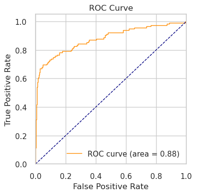

```
{'C': 1.0,
 'class_weight': {0: 0.455, 1: 1},
 'dual': False,
 'fit_intercept': True,
 'intercept_scaling': 1,
 'l1_ratio': None,
 'max_iter': 1000,
 'multi_class': 'auto',
 'n_jobs': None,
 'penalty': 'l2',
 'random_state': 42,
 'solver': 'lbfgs',
 'tol': 0.0001,
 'verbose': 0,
 'warm_start': False}
```

```python
final_report, E1_d = run_experiment('E1-d : Regressão Logística - Balanceamento "Undersample" com ENN',
                              LogisticRegression(random_state=42,
                                                 max_iter=1000,
                                                 #multi_class='ovr',
                                                 #penalty='l2',
                                                 #solver='sag',
                                                 class_weight={0:0.0065,1:1}
                                                ),
                              X_train_enn, y_train_enn, X_test_enn, y_test_enn, X_val, y_val,
                              final_report)
E1_b.get_params()
```

## E1-e: Regressão Logística - Ajuste Paramétrico

#### Model

```
-------------------------------------------------------------
E1-e : Regressão Logística - Ajuste Paramétrico - LogisticRegression
-------------------------------------------------------------
Relatório de Classificação:
          index  precision  recall  f1-score  support
0             0       1.00    0.81      0.89    14130
1             1       0.03    0.80      0.05       99
2      accuracy       0.81    0.81      0.81        0
3     macro avg       0.51    0.80      0.47    14229
4  weighted avg       0.99    0.81      0.89    14229
-------------------------------------------------------------
```

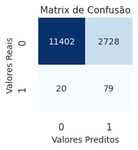

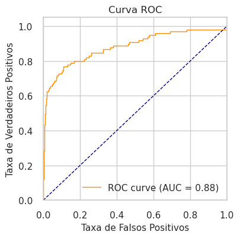

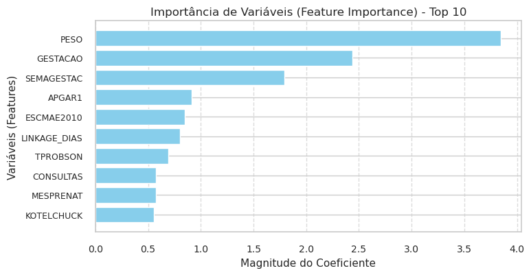

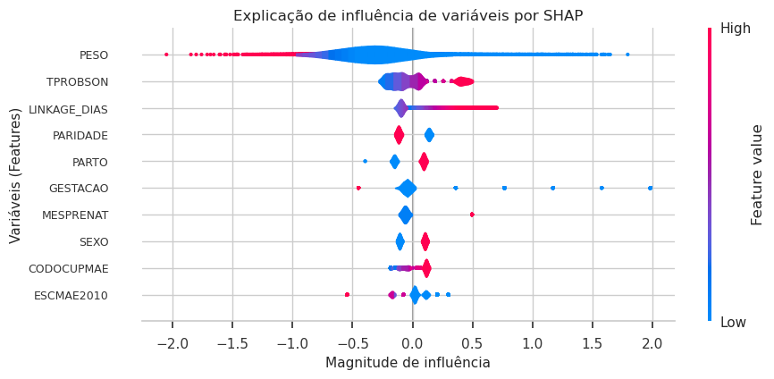

```
-------------------------------------------------------------
E1-ev: Validação - LogisticRegression
-------------------------------------------------------------
Relatório de Classificação:
          index  precision  recall  f1-score  support
0             0       1.00    0.72      0.84    17671
1             1       0.02    0.86      0.04      115
2      accuracy       0.72    0.72      0.72        0
3     macro avg       0.51    0.79      0.44    17786
4  weighted avg       0.99    0.72      0.83    17786
-------------------------------------------------------------
Accuracy: 0.7219161137973688
Confusion Matrix
[[12741  4930]
 [   16    99]]
```

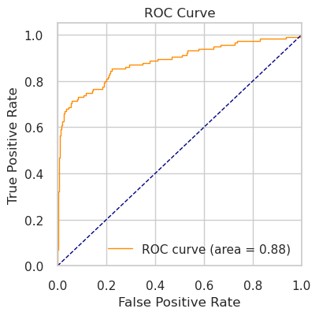

```
{'C': 1.0,
 'class_weight': {0: 0.0028, 1: 1},
 'dual': False,
 'fit_intercept': True,
 'intercept_scaling': 1,
 'l1_ratio': None,
 'max_iter': 1000,
 'multi_class': 'auto',
 'n_jobs': None,
 'penalty': 'l2',
 'random_state': 42,
 'solver': 'lbfgs',
 'tol': 0.0001,
 'verbose': 0,
 'warm_start': False}
```

```python
# Usando solver='sag' deu mesma coisa
final_report, E1_e = run_experiment('E1-e : Regressão Logística - Ajuste Paramétrico',
                           LogisticRegression(random_state=42,
                                                 max_iter=1000,
                                                 class_weight={0:0.0028,1:1}),
                              X_train, y_train, X_test, y_test, X_val, y_val,
                              final_report)
E1_e.get_params()
```

#### Grid Search

```python
'''
from sklearn.model_selection import GridSearchCV

log_reg = LogisticRegression()

# Define the grid of parameters to search
param_grid = {
    'solver': ['sag'],  # Solvers for logistic regression
    'penalty': ['l2'],  # Regularization penalty
    'multi_class': ['ovr'],  # Multiclass strategy
    'class_weight': [{0: 1, 1: 1},{0: 5, 1: 1}, {0: 6, 1: 1}, {0: 7, 1: 1}, {0: 8, 1: 1}, {0: 9, 1: 1}, {0: 10, 1: 1},  {0: 20, 1: 1} ],  # Class weights
    'max_iter': [10,50,100,150,200,250,300,350,400,450,500,600,700,800,900]  # Maximum number of iterations
}


# Perform fine-tuning grid search with cross-validation
grid_search = GridSearchCV(log_reg, param_grid, cv=5, scoring='recall')
grid_search.fit(X_train, y_train)

# Print the results of fine-tuning grid search
print("Fine-Tuning Grid Search Results:")
print("")

# Print the best parameters found by fine-tuning grid search
print("Best Parameters:")
print(grid_search.best_params_)
print("")

# Print the best cross-validation score found by fine-tuning grid search
print("Best Cross-Validation Score:", grid_search.best_score_)
print("")

# Evaluate the best model on the validation set
best_model = grid_search.best_estimator_
val_score = best_model.score(X_val, y_val)
print("Validation Set Score:", val_score)
'''
```

[output not shown]

## E1-f: Regressão Logística - Balanceamento "Oversample" ADASYN

#### Simple Plan

```
Accuracy: 0.9700611427366646
Confusion Matrix
[[13751   379]
 [   47    52]]
```

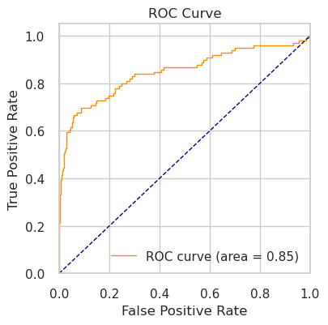

```python
LR = LogisticRegression(random_state=42, max_iter=1000).fit(X_over, y_over)
initial_evaluation(LR, X_test, y_test)
```

#### Model

```
-------------------------------------------------------------
E1-f: Balanceamento "Oversample" ADASYN - LogisticRegression
-------------------------------------------------------------
Relatório de Classificação:
          index  precision  recall  f1-score  support
0             0       1.00    0.62      0.76    14130
1             1       0.02    0.85      0.03       99
2      accuracy       0.62    0.62      0.62        0
3     macro avg       0.51    0.73      0.40    14229
4  weighted avg       0.99    0.62      0.76    14229
-------------------------------------------------------------
```

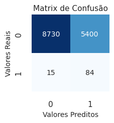

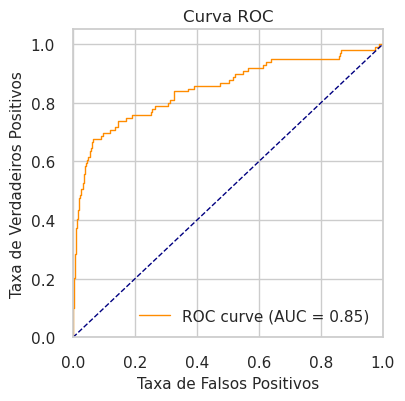

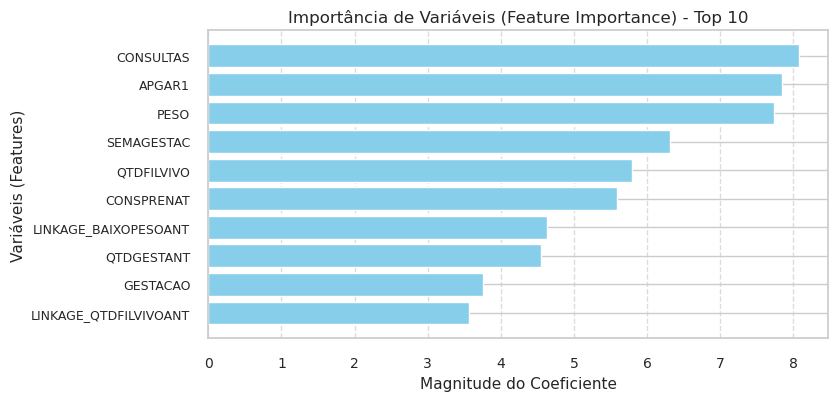

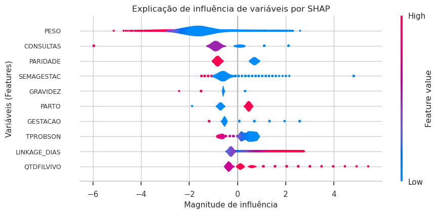

```
-------------------------------------------------------------
E1-fv: Validação - LogisticRegression
-------------------------------------------------------------
Relatório de Classificação:
          index  precision  recall  f1-score  support
0             0       1.00    0.51      0.67    17671
1             1       0.01    0.90      0.02      115
2      accuracy       0.51    0.51      0.51        0
3     macro avg       0.51    0.70      0.35    17786
4  weighted avg       0.99    0.51      0.67    17786
-------------------------------------------------------------
Accuracy: 0.5076464635106264
Confusion Matrix
[[8926 8745]
 [  12  103]]
```

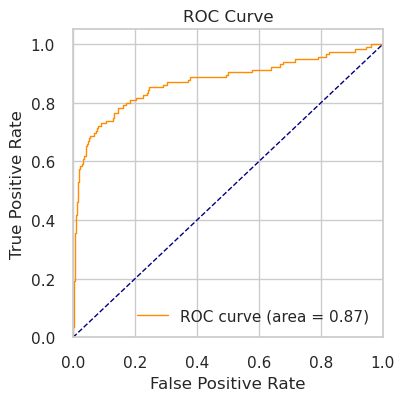

```
{'C': 1.0,
 'class_weight': {0: 0.07, 1: 1},
 'dual': False,
 'fit_intercept': True,
 'intercept_scaling': 1,
 'l1_ratio': None,
 'max_iter': 1000,
 'multi_class': 'auto',
 'n_jobs': None,
 'penalty': 'l2',
 'random_state': 42,
 'solver': 'lbfgs',
 'tol': 0.0001,
 'verbose': 0,
 'warm_start': False}
```

```python
final_report, E1_f = run_experiment('E1-f: Balanceamento "Oversample" ADASYN',
                              LogisticRegression(random_state=42, max_iter=1000,
                                                 #solver='sag', penalty='l2',
                                                 class_weight={0:0.07,1:1}
                                                ),
                                                X_over, y_over, X_test, y_test, X_val, y_val,
                                                final_report)
E1_f.get_params()
```

# E2: Naive Bayes

## E2-a: Modelo Naive Bayes - ComplementNB - Baseline

```
-------------------------------------------------------------
E2-a : Naive Bayes - ComplementNB - ComplementNB
-------------------------------------------------------------
Relatório de Classificação:
          index  precision  recall  f1-score  support
0             0       1.00    0.80      0.88    14130
1             1       0.02    0.75      0.05       99
2      accuracy       0.79    0.79      0.79        0
3     macro avg       0.51    0.77      0.47    14229
4  weighted avg       0.99    0.79      0.88    14229
-------------------------------------------------------------
```

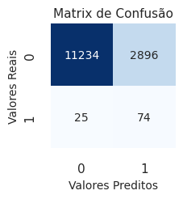

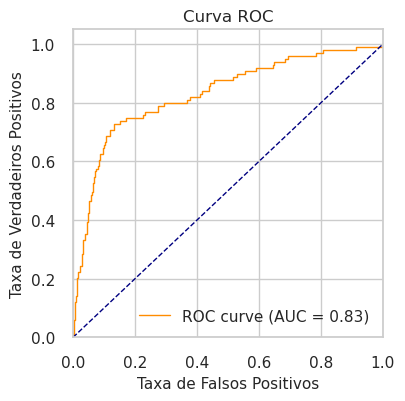

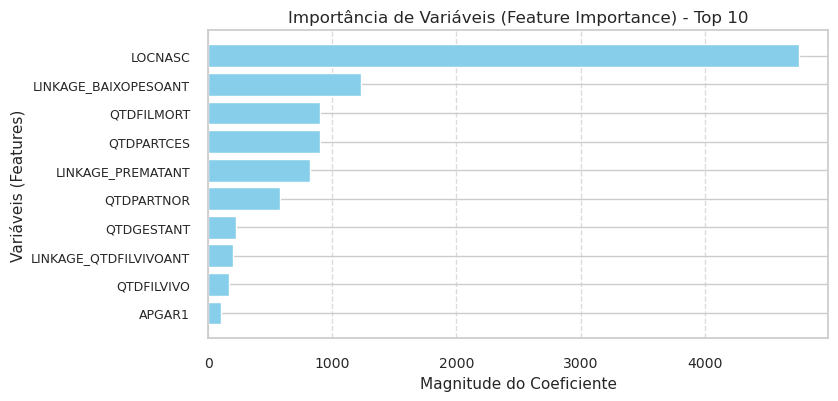

```
-------------------------------------------------------------
E2-av: Validação - ComplementNB
-------------------------------------------------------------
Relatório de Classificação:
          index  precision  recall  f1-score  support
0             0       1.00    0.79      0.88    17671
1             1       0.02    0.75      0.04      115
2      accuracy       0.79    0.79      0.79        0
3     macro avg       0.51    0.77      0.46    17786
4  weighted avg       0.99    0.79      0.87    17786
-------------------------------------------------------------
Accuracy: 0.7867986056448892
Confusion Matrix
[[13908  3763]
 [   29    86]]
```

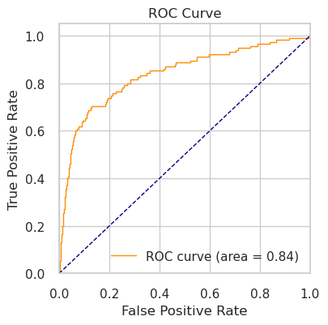

```python
final_report, E2_a = run_experiment('E2-a : Naive Bayes - ComplementNB',
                              ComplementNB(),
                              X_train, y_train, X_test, y_test, X_val, y_val,
                              final_report)
#80/76
```

## E2-b: Modelo Naive Bayes - ComplementNB - Ajuste Fino

```
-------------------------------------------------------------
E2-b : Naive Bayes - ComplementNB - Ajuste Fino - ComplementNB
-------------------------------------------------------------
Relatório de Classificação:
          index  precision  recall  f1-score  support
0             0       1.00    0.80      0.89    14130
1             1       0.03    0.75      0.05       99
2      accuracy       0.80    0.80      0.80        0
3     macro avg       0.51    0.78      0.47    14229
4  weighted avg       0.99    0.80      0.89    14229
-------------------------------------------------------------
```

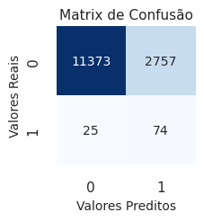

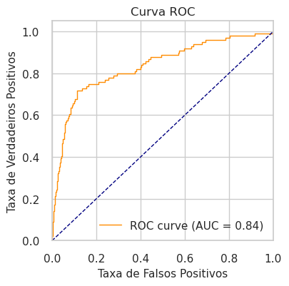

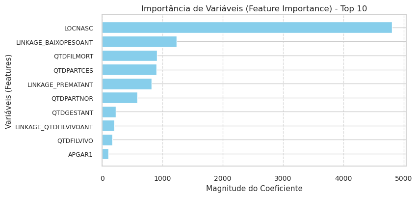

```
-------------------------------------------------------------
E2-bv: Validação - ComplementNB
-------------------------------------------------------------
Relatório de Classificação:
          index  precision  recall  f1-score  support
0             0       1.00    0.80      0.89    17671
1             1       0.02    0.73      0.04      115
2      accuracy       0.79    0.79      0.79        0
3     macro avg       0.51    0.76      0.46    17786
4  weighted avg       0.99    0.79      0.88    17786
-------------------------------------------------------------
Accuracy: 0.7947824131339256
Confusion Matrix
[[14052  3619]
 [   31    84]]
```

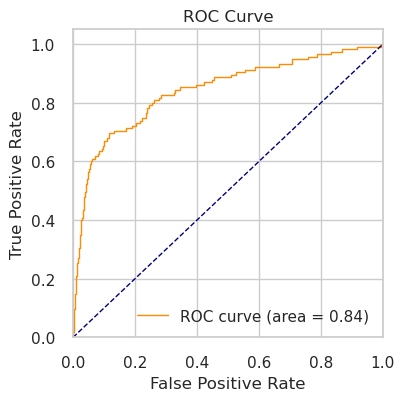

```python
_, _ = run_experiment('E2-b : Naive Bayes - ComplementNB - Ajuste Fino',
                              ComplementNB(alpha=0.001),
                              X_train, y_train, X_test, y_test, X_val, y_val,
                              final_report)
```

```
-------------------------------------------------------------
E2-b : Naive Bayes - ComplementNB - Ajuste Fino - ComplementNB
-------------------------------------------------------------
Relatório de Classificação:
          index  precision  recall  f1-score  support
0             0       1.00    0.81      0.89    14130
1             1       0.03    0.74      0.05       99
2      accuracy       0.81    0.81      0.81        0
3     macro avg       0.51    0.77      0.47    14229
4  weighted avg       0.99    0.81      0.89    14229
-------------------------------------------------------------
```

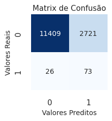

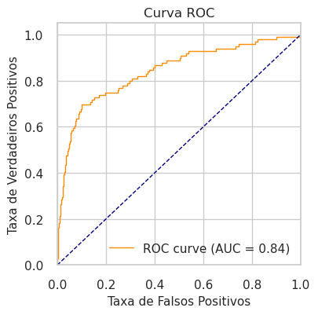

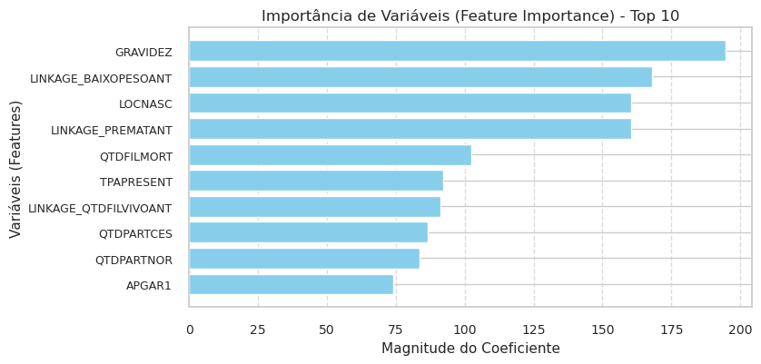

```
-------------------------------------------------------------
E2-bv: Validação - ComplementNB
-------------------------------------------------------------
Relatório de Classificação:
          index  precision  recall  f1-score  support
0             0       1.00    0.80      0.89    17671
1             1       0.02    0.74      0.05      115
2      accuracy       0.80    0.80      0.80        0
3     macro avg       0.51    0.77      0.47    17786
4  weighted avg       0.99    0.80      0.88    17786
-------------------------------------------------------------
Accuracy: 0.8009108287417069
Confusion Matrix
[[14160  3511]
 [   30    85]]
```

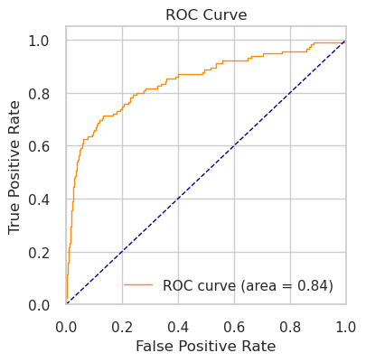

```python
# Balanceado
final_report, E2_b = run_experiment('E2-b : Naive Bayes - ComplementNB - Ajuste Fino',
                              ComplementNB(alpha=30),
                              X_train_bal, y_train_bal, X_test, y_test, X_val, y_val,
                              final_report)
```

```
-------------------------------------------------------------
E2-b : Naive Bayes - ComplementNB - Ajuste Fino - ComplementNB
-------------------------------------------------------------
Relatório de Classificação:
          index  precision  recall  f1-score  support
0             0       1.00    0.83      0.91    14130
1             1       0.03    0.73      0.06       99
2      accuracy       0.83    0.83      0.83        0
3     macro avg       0.51    0.78      0.48    14229
4  weighted avg       0.99    0.83      0.90    14229
-------------------------------------------------------------
```

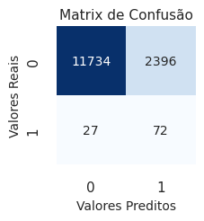

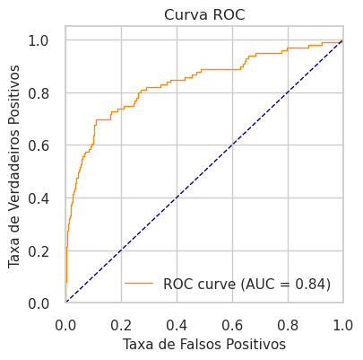

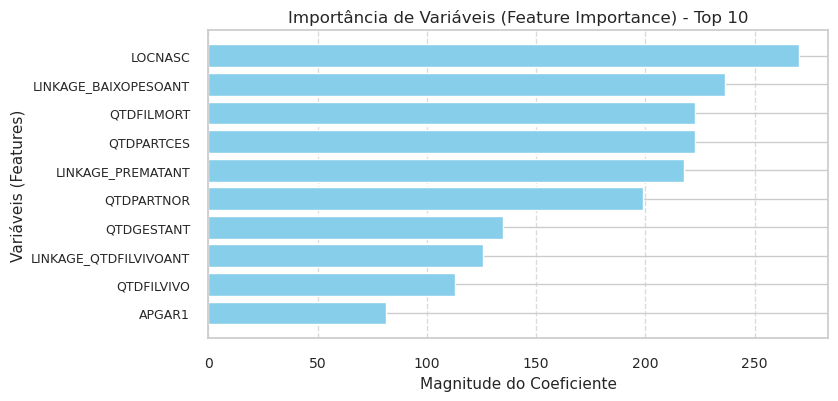

```
-------------------------------------------------------------
E2-bv: Validação - ComplementNB
-------------------------------------------------------------
Relatório de Classificação:
          index  precision  recall  f1-score  support
0             0       1.00    0.83      0.91    17671
1             1       0.03    0.75      0.05      115
2      accuracy       0.83    0.83      0.83        0
3     macro avg       0.51    0.79      0.48    17786
4  weighted avg       0.99    0.83      0.90    17786
-------------------------------------------------------------
Accuracy: 0.8285730349713257
Confusion Matrix
[[14651  3020]
 [   29    86]]
```

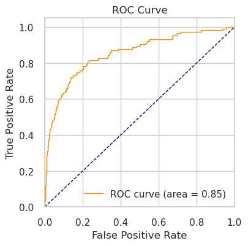

```python
# Balanceado Oversample
_, _ = run_experiment('E2-b : Naive Bayes - ComplementNB - Ajuste Fino',
                              ComplementNB(alpha=2000),
                              X_over, y_over, X_test, y_test, X_val, y_val,
                              final_report)
```